# Reproduction of Simulation 1 by Jamieson, Crump & Hannah (2012)

Frederik Aust

13.1.2015

To validate this implementation of Minerva-AL, I reproduced a simulation study reported in Jamieson, Crump & Hannah (2012).

# Simulation of acquisition and extinction (Section 1)

I created cue, outcome and context vectors and defined the number of trials and replications according to the specifications in the paper.

```r
n_features <- 120
cue_features <- 1:100
a <- context <- outcome <- rep(0, n_features)

a[1:20] <- 1
outcome[101:120] <- 1
context[81:100] <- 1

acquisition_event <- a + context + outcome
extinction_event <- probe <- a + context
```

```r
n_replications <- 100
n_trials <- 200

p_encode <- c(1/3, 2/3, 1)
```

```r
sim_results <- matrix(0, ncol = n_trials, nrow = length(p_encode))

for (r in 1:n_replications) {
  for (i in 1:3) {
    # Memory is empty on first trial
    normalized_echo <- probe_memory(probe, NULL, cue_features)
    expectancy <- expect_event(outcome, normalized_echo)
    memory <- learn(
      normalized_echo
      , acquisition_event
      , p_encode[i]
      , NULL
    )

     # Acquisition trials
    for(j in 2:(n_trials / 2)) {
      normalized_echo <- probe_memory(probe, memory, cue_features)
      expectancy <- c(expectancy, expect_event(outcome, normalized_echo))
      memory <- learn(
        normalized_echo
        , acquisition_event
        , p_encode[i]
        , memory
      )
    }

    # Extinction trials
    for(j in ((n_trials / 2) + 1):n_trials) {
      normalized_echo <- probe_memory(probe, memory, cue_features)
      expectancy <- c(expectancy, expect_event(outcome, normalized_echo))
      memory <- learn(
        normalized_echo
        , extinction_event
        , p_encode[i]
        , memory
      )
    }

    sim_results[i, ] <- sim_results[i, ] + expectancy
  }
}

sim_results <- sim_results / n_replications # Mean of replications
```

## Results

The resulting expectancies correspond nicely to those reported by Jamieson, Hannah & Crump (2012) in Figure 1.

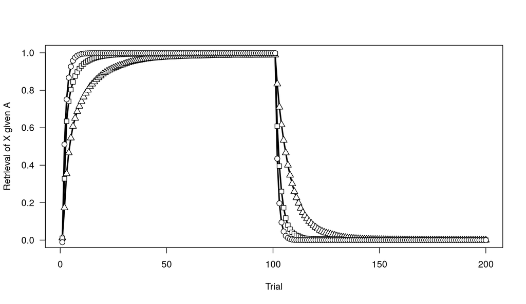

As a comparison, the following plot shows the results from the reference implementation I received from Randall Jamieson (thanks!).

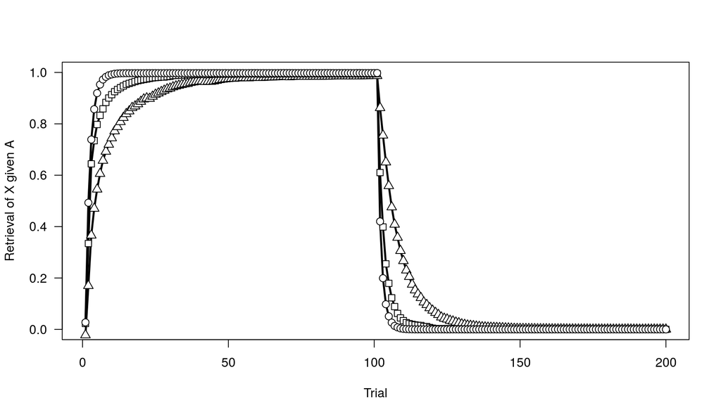

```r
acquisition_files <- list.files(path = "reference_implementation/results", pattern = "Acquisition", full.names = TRUE)

acquisition_extinction <- lapply(
  acquisition_files
  , read.delim
  , skip = 3
  , nrows = 24
  , sep = ""
  , header = FALSE
) %>%
  setNames(
    nm = stringr::str_extract(basename(acquisition_files), "\\d+") %>%
      gsub("0", "0.", .)
  ) %>%
  bind_rows(.id = "L") %>%
  mutate(V2 = as.factor(V2)) %>%
  group_by(L) %>%
  summarise_if(is.numeric, mean)
```

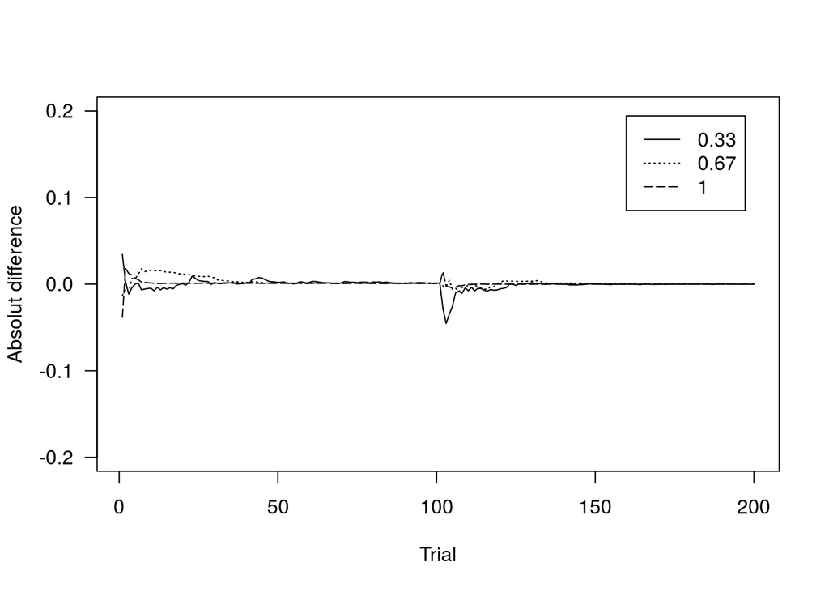

```r
prediction_differences <- sim_results - as.matrix(acquisition_extinction[, -1])

plot(
  1:200
  , rep(NA, 200)
  , ylim = c(-0.2, 0.2)
  , lwd = 2.5
  , xlab = "Trial"
  , ylab = "Absolut difference"
  , las = 1
)

matlines(
  t(prediction_differences)
  , col = "black"
  , lty = c(1, 3, 5)
)

legend("topright", inset = 0.05, legend = unlist(acquisition_extinction[, 1]), lty = c(1, 3, 5))
```

```r
summary(as.vector(prediction_differences))
```

```
##       Min.    1st Qu.     Median       Mean    3rd Qu.       Max.
## -4.534e-02 -2.364e-05  7.253e-04  6.591e-04  1.244e-03  3.427e-02
```

Additionally, the following plots visualize the information encoded for cue and outcome features across acquisition and extinction trials. The data are taken from one of the 100 simulations with encoding probability $L = 1$.

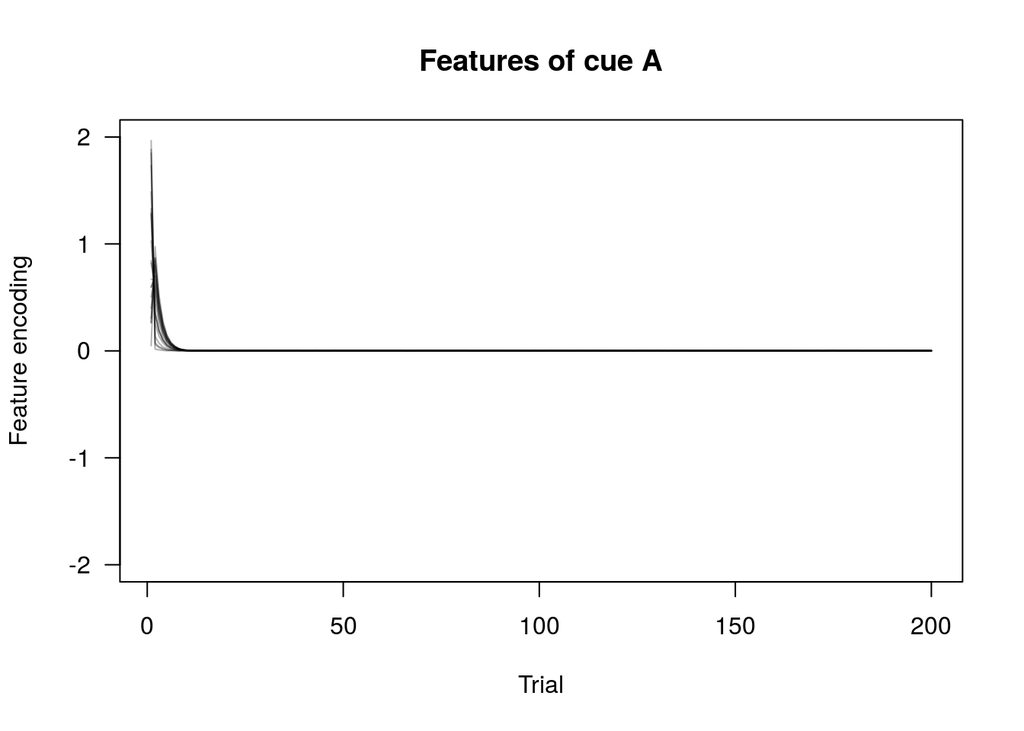

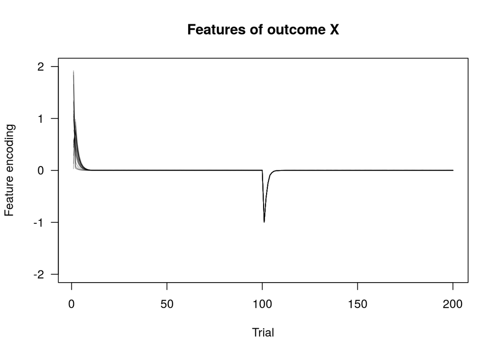

# Simulation of reacquisition (Section 1)

```r
b <- rep(0, n_features)

b[21:40] <- 1
control_event <- b + context + outcome
control_probe <- b + context
```

```r
n_replications <- 100
n_trials <- 200
```

```r
reacquisition_sim_results <- control_sim_results <- matrix(NA, ncol = n_trials, nrow = length(p_encode) * n_replications)

for (i in 1:length(p_encode)) {
  for (r in 1:n_replications) {
    # Memory is empty on first trial
    normalized_echo <- probe_memory(probe, NULL, cue_features)
    expectancy <- expect_event(outcome, normalized_echo)
    memory <- learn(
      normalized_echo
      , acquisition_event
      , p_encode[i]
      , NULL
    )

    # Acquisition trials
    for(j in 2:50) {
      normalized_echo <- probe_memory(probe, memory, cue_features)
      expectancy <- c(expectancy, expect_event(outcome, normalized_echo))
      memory <- learn(
        normalized_echo
        , acquisition_event
        , p_encode[i]
        , memory
      )
    }

    # Extinction trials
    for(j in 51:100) {
      normalized_echo <- probe_memory(probe, memory, cue_features)
      expectancy <- c(expectancy, expect_event(outcome, normalized_echo))
      memory <- learn(
        normalized_echo
        , extinction_event
        , p_encode[i]
        , memory
      )
    }

    # Reacquisition trials
    reacquisition_memory <- memory
    reacquisition_expectancy <- expectancy

    for(j in 101:200) {
      normalized_echo <- probe_memory(probe, reacquisition_memory, cue_features)
      reacquisition_expectancy <- c(reacquisition_expectancy, expect_event(outcome, normalized_echo))
      reacquisition_memory <- learn(
        normalized_echo
        , acquisition_event
        , p_encode[i]
        , reacquisition_memory
      )
    }

    # Control trials
    control_memory <- memory
    control_expectancy <- expectancy

    for(j in 101:200) {
      normalized_echo <- probe_memory(control_probe, control_memory, cue_features)
      control_expectancy <- c(control_expectancy, expect_event(outcome, normalized_echo))
      control_memory <- learn(
        normalized_echo
        , control_event
        , p_encode[i]
        , control_memory
      )
    }

    reacquisition_sim_results[(i-1)*n_replications + r, ] <- reacquisition_expectancy
    control_sim_results[(i-1)*n_replications + r, ] <- control_expectancy
  }
}
```

## Results

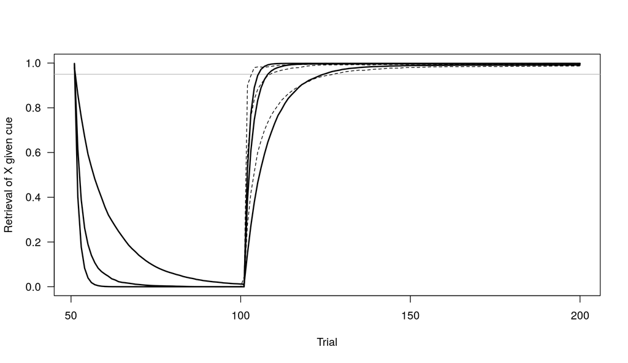

| Condtion | 0.33 | 0.67 | 1 |
| --- | --- | --- | --- |
| Reacquisition | 22.28 (0.67) | 8.06 (0.2) | 5.53 (0.09) |
| Control | 25.86 (0.64) | 8.71 (0.29) | 3.07 (0.07) |

As a comparison, the following plot shows the results from the reference implementation I received from Randall Jamieson (thanks!).

```r
reacquisition_files <- list.files(path = "reference_implementation/results", pattern = "Reacquisition\\_\\d+", full.names = TRUE)

reacquisition <- lapply(
  reacquisition_files
  , read.delim
  , skip = 3
  , nrows = 24
  , sep = ""
  , header = FALSE
) %>%
  setNames(
    nm = stringr::str_extract(basename(reacquisition_files), "\\d+") %>%
      gsub("0", "0.", .)
  ) %>%
  bind_rows(.id = "L") %>%
  mutate(V2 = as.factor(V2))

mean_reacquisition <- reacquisition %>%
  group_by(L) %>%
  summarise_if(is.numeric, mean)
```

```r
reacquisition_control_files <- list.files(path = "reference_implementation/results", pattern = "Reacquisition\\_\\D+", full.names = TRUE)

reacquisition_control <- lapply(
  reacquisition_control_files
  , read.delim
  , skip = 3
  , nrows = 24
  , sep = ""
  , header = FALSE
) %>%
  setNames(
    nm = stringr::str_extract(basename(reacquisition_control_files), "\\d+") %>%
      gsub("0", "0.", .)
  ) %>%
  bind_rows(.id = "L") %>%
  mutate(V2 = as.factor(V2))

mean_reacquisition_control <- reacquisition_control %>%
  group_by(L) %>%
  summarise_if(is.numeric, mean)
```

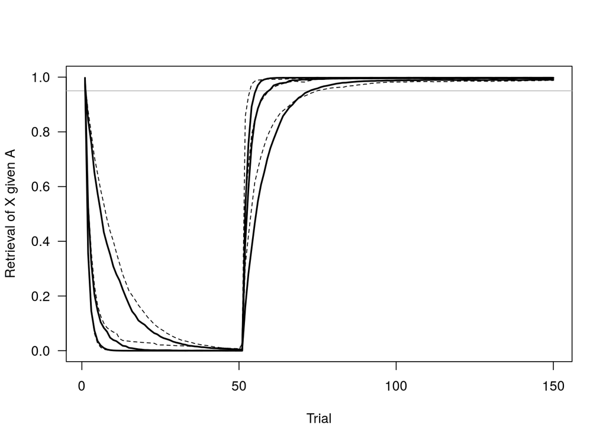

```r
reacquisition_results <- matrix(NA, ncol = 3, nrow = 2)

trails_to_master <- function(x) data.frame(n_trials = min(which(x >= 0.95)))

reacquisition_trial_counts <- reacquisition %>%
  group_by(L, V2) %>%
  do(trails_to_master(.[, 104:ncol(reacquisition)])) %>%
  group_by(L) %>%
  summarize(n_trials = mean_se(n_trials))

reacquisition_control_trial_counts <- reacquisition_control %>%
  group_by(L, V2) %>%
  do(trails_to_master(.[, 104:ncol(reacquisition_control)])) %>%
  group_by(L) %>%
  summarize(n_trials = mean_se(n_trials))

knitr::kable(
  bind_rows(Reacquition = reacquisition_trial_counts, Control = reacquisition_control_trial_counts, .id = "Condition") %>%
    spread(L, n_trials) %>%
    arrange(desc(Condition))
)
```

| Condition | 0.33 | 0.67 | 1 |
| --- | --- | --- | --- |
| Reacquition | 22.12 (0.95) | 8.79 (0.88) | 5.67 (0.18) |
| Control | 24.5 (1.11) | 10.17 (0.58) | 3.17 (0.16) |

The following plot compares initial and reacquisition.

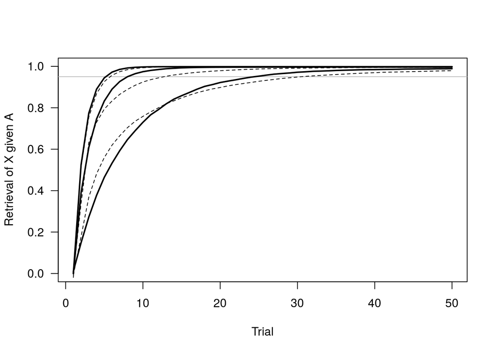

```r
plot(
  1:50
  , rep(0, 50)
  , pch = NA
  , ylim = c(0, 1)
  , lwd = 2.5
  , xlab = "Trial"
  , ylab = "Retrieval of X given A"
  , las = 1
)

abline(h = 0.95, col = "grey")

for(i in 1:length(p_encode)) {
  lines(colMeans(reacquisition_sim_results[(1:n_replications) + (i-1)*n_replications, 1:50]), lty = 2)
}

for(i in 1:length(p_encode)) {
  lines(colMeans(reacquisition_sim_results[(1:n_replications) + (i-1)*n_replications, 101:150]), lwd = 2)
}
```

And the same for the reference implementation.

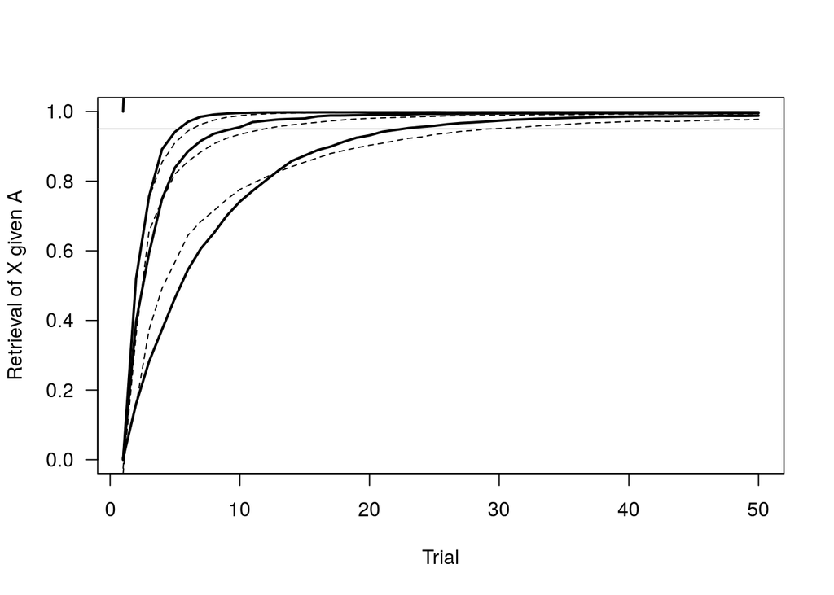

```r
plot(
  1:50
  , rep(NA, 50)
  , ylim = c(0, 1)
  , lwd = 2.5
  , xlab = "Trial"
  , ylab = "Retrieval of X given A"
  , las = 1
)

abline(h = 0.95, col = "grey")

matlines(
  cbind(1:50, t(as.matrix(mean_reacquisition[, 102:151])))
  , col = "black"
  , lty = 1
  , lwd = 2
)

matlines(
  cbind(1:50, t(as.matrix(mean_reacquisition[, 2:51])))
  , col = "black"
  , lty = 2
)
```

# References

Jamieson, R. K., Crump, M. J. C., & Hannah, S. D. (2012). An instance theory of associative learning. *Learning & Behavior*, 40(1), 61–82. doi:[10.3758/s13420-011-0046-2](http://dx.doi.org/10.3758/s13420-011-0046-2)